# Lab 2-2

Identifying Threats of Contamination to Merced County Rivers through Common Geoprocessing Tasks

Created by Madeline Brown

Updated 08/08/2022

University of California, Merced  
School of Engineering  
Spatial Analysis and Modeling (ENGR 180)

###### Key deliverables are in RED.

###### File and folder names are underlined

###### *Tools and key steps are italicized*

### Introduction

**Skills: Opening Pre-Existing Projects, Creating Geodatabases, Joins, Intersect, Clip, Buffer, Dissolve**  
**Case Study Scenario**: You completed importing flat file data for Merced County wells and correctly projecting the well data into a projection appropriate for the regional scale. The well locations, however, dont have contaminant information! You will join contaminant information, then isolate wells within a certain distance of rivers in Merced County in preparation for the upcoming meeting.

**Prep**: Download cdfg_100k_2003_6.zip, a 1:100,000 scale hydrography shapefile covering the state of California [1] from Catcourses and add it to your previously created CaseStudy2-1Data folder in Classfiles. Unzip the folder or else it wont show up properly in ArcGIS Pro.

### Part 1: Opening a Pre-existing Project

1. Log into Classfiles on the computer lab computer, and then access ArcGIS Pro.
2. Make sure you are signed into ArcGIS in the top right corner of the software.
3. Instead of creating a new project, access your previously created Case Study 2-1 by clicking on it under Recent Projects on the left

[figure not shown]

*The left side of your home base in ArcGIS Pro shows recent projects*

### Part 2: Creating a Geodatabase and Importing Data

When you created your project for 2-1, ArcGIS Pro automatically created a folder structure and geodatabase for you! You can see this in your Catalog Pane.

1. Within the *Catalog* pane, click the dropdown arrow for *Databases*. This is your project geodatabase. Within the geodatabase (.gdb) you should see all of the layers you created in 1-1.
2. We want to add a second, new geodatabase to bring in data for 2-1 to keep our project compartmentalized.

But, what even is a geodatabase(.gdb/GDB)?!  
According to Esri, a geodatabase is “a container that stores spatial and attribute data.” GDBs can contain feature classes that store point, line, or polygon features. They can also store tabular data that lack spatial attributes, such as attribute tables. The GDB assigns unique, integer IDs as identifiers for rows in GDB tables [2].

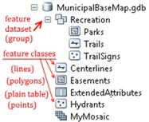

*Components of a Geodatabase*

There are three types of GDBs within the ArcGIS suite, each with a different history and use case [3]. You will typically use File GDBs for your typical use cases. Companies with multiple GIS users use Enterprise Geodatabases to manage multiple people working on the same dataset at once.  
It’s important to note the difference between feature datasets and feature classes. Certain operations cannot be performed if your data are in feature datasets, for instance. For more information, refer the “Feature classes” and “Feature Datasets” under the ArcGIS documentation. You typically will only create feature datasets in special circumstances (e.g. creating parcel fabrics).  
It helps to look at the symbology to understand what’s what. A geodatabase is represented by a canister. A feature dataset is a stack of 3 squares, try to think of them as file folders. Individual feature classes have symbols for points, lines, polygons, rasters, or tables. There are many ways of creating GDBs in ArcGIS Pro. One simple way is to use the built-in *Catalog*.

3. Right click on the *Databases* section of *Catalog* and navigate to *New* -> *File Geodatabase*.
4. When the window for *New File Geodatabase* pops up, confirm it is the same location as your 2-1 geodatabase
5. Rename the resulting file CaseStudy2-2 and click *Save*. Now you can import shapefiles or non-shape tabular data into your GDB.
6. Right click on the GDB that you have just created in *Catalog*.
7. Navigate to *Import* -> *Feature class (single)* to import a single shapefile into your GDB. Note that you will have to specify a name for the feature class under “Output Feature Class” in the resulting window.
8. Import the cdfg_100k_2003_6 shapefile into your new geodatabase CaseStudy2-2, and name it CaliforniaRivers.
9. Confirm all of your projections for each layer. If you have any projections that are not in the same projection as MercedCountyCAT, project the layer to match the Spatial Reference of MercedCountyCAT(as learned in Case Study 2-1).
10. If you reproject a layer, add PRJ to the output filename…e.g. CaliforniaRiversPRJ.

Submit screenshots verifying each layer is in the same projection. Hint: projections are part of spatial reference data

1. Right click and remove the original CaliforniaRivers layer you created from the *Table of Contents*. It will still be in the geodatabase, but we don’t want to have it in the *Table of Contents* so we don’t accidentally work on the wrong layer.

### Part 3: Setting Your Default Geodatabase

1. Look at your two geodatabases in *Catalog*: Which as a little house icon?
2. Right click on your new CaseStudy2-2 GDB and select “Make Default” Now, every time you run a geoprocessing task, it will output the resulting dataset into your GDB for 2-2.

Submit a screenshot showing your *Catalog* Pane, including both geodatabases, all their content, and CaseStudy2-2 geodatabase set to your Default Geodatabase.

### Part 4: Preparing to Join Spatial Data

We ended Lab 2-1 with our well locations in the correct projection.

1. Open the *attribute table* (Rt click - Attribute Table) for your well locations. We’re going to map contaminants, but see how there aren’t any contaminants listed in the attribute data?

We are going to *JOIN* aspatial data (another table with no spatial data, aka coordinates) to our spatial data (well locations) using a *unique identifier*. Remember that when we converted from DMS to DD, we saved the columns of Well Name, Longitude, and Latitude?  
We can join tables if we have a “unique id” – a field where the names match PERFECTLY. In this case, it is the Well Name.  
Create and submit a scenario where you’d join SPATIAL and ASPATIAL data. Clearly identify the spatial component with the aspatial component, as well as the unique identifier the two would be joined by. (These can be hypothetical).  
Start by thinking about types of unique identifiers - Drivers License numbers, Student ID numbers, License plates…things that there should only be one of…

This concept can be tricky. You can find an example on the web if you feel stuck/stumped. If you use a web example, you MUST cite it AND explain it in your own words for full credit, as well as drawn your own table.

*Example*

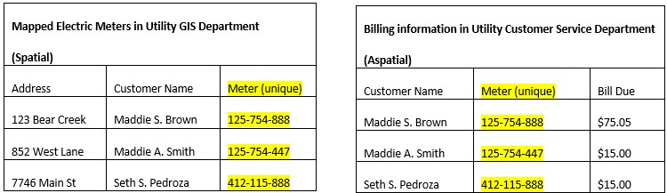

We need to take our external aspatial CSV and import it into our geodatabase. This will generate unique object identifiers (OIDs) for each observation.

1. Open the *Catalog* sidebar and navigate to your project geodatabase.
2. Right click the geodatabase and select *Import* -> *Table.*
3. This will open a *Table to Table* window in your *Geoprocessing* pane on the right.
4. Set your Parameters to import the gama_edf_merced_clean.csv.
5. Name your output GAMAWellsData. Click *Run.*

### Part 5: Operations on Tabular Data in ArcGIS

First, we want to isolate well data in the aspatial GAMAWellsData table to just the wells that are contaminated.

Let’s start by summarizing the well information by computing mean, min and max concentrations for hexavalent chromium (CR6).

1. Right click on your new GAMAWellsData table and open it. [If it isn’t in your *Table of Contents*, drag and drop it in from *Catalog*]
2. First let’s select the entries with CR6 contamination from the well info table. Click on the *Select by Attributes* button in the ribbon toolbar up top.
3. We want to select all entries from our well table where CHEMICAL = CR6. Use *+New Expression* to isolate all of the Wells that have CR6 using the drop-down options. Press *OK* when you are done.

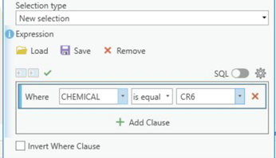

*Creating a new selection*

4. In your attribute table, click on the little blue stacks at the bottom so that it switches our displayed rows to just those we selected with the query above.
5. Next, let’s summarize the RESULT column by the WELL NAME column. Right click on the WELL NAME column header and navigate to *Summarize.* Since we switched to our selected query rows, it will summarize just those.

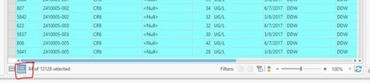

*Isolating selected wells*

This will open a *Summary Statistics* pane.

6. We want to retain the CHEMICAL and the WELL NAME field, so those are our Case Fields. We want to compute the statistics of minimum, maximum, and average (mean) from the RESULT column, so those are our Statistics Field(s). Click *Run.* This adds a new table to your *Standalone Tables* in the *Table of Contents*.

### Part 6: Officially Joining Spatial + Aspatial Data

Now we are ready to join this information to our well location layer.

1. Right click on GAMAWellsDDPRJ in your *Table of Contents* and access *Joins and Relates* -> *Add Join*…
2. In the subsequent window, perform the join operation based on the WELL NAME field in both your layer and your summary statistic table. By selecting “Keep all records”, you will retain well locations that do not have a matching summary in your summary table. ArcGIS Pro will represent these non-existent pairings with a null value.
3. Click *Run.*

Great! You have joined aspatial data (data with no spatial information) to spatial data (data WITH spatial information/coordinates). Our data are ready for us to geoprocess!

### Part 7: Vector Data Operations - Clip and Intersect

There are several common tools (spatial operations) that most GISers use on a regular basis. This section of the lab will walk you through some of them.  
*Intersect* and *Clip* are two examples of spatial operations that reduce the scope of various input data sets. *Clip* can be thought of as a cookie cutter; We can *clip* a vector data set to a region defined by a polygon.  
If we are only interested in the rivers and streams within Merced County, we can *Clip* this statewide dataset to match the extent of the Merced County boundary.

1. Review the documentation for the *Clip* tool [4] and use it to *clip* your CaliforniaRiversPRJ feature class to the Merced County boundary.
2. You can search for *Clip* and other commonly used tools through the *Tools* *Ribbon* OR use the search bar. Make sure to select Merced County only before you run your Clip. You can do that simply by clicking on it once with your Select tool.
3. Save the output clipped layer as MercedRiversClipped to your Default Geodatabase

*Intersect* is very similar to *Clip*, however it preserves all features that *intersect*, including borders of layers.

4. Try *intersecting* Merced County and the rivers layers and look at the attributes table to see the different result (right click in the *Table of Contents – Open Attribute Table*).
5. Save the output intersected layer as MercedRiversIntersect to your Default Geodatabase.

In a written response, compare and contrast the clip and intersect geoprocessing tasks and include a screenshot of either layer for submission. You can use supplemental resources in your comparison, just be sure to cite them!

### Part 8: Buffering Features

You are tasked with identifying the rivers that could potentially be affected by groundwater contamination from the sites that had any observations of hexavalent chromium (CR6). You will make a production quality map for the public next week.  
Your manager instructs you to identify all areas that lie within 10 meters of potentially contaminated wells. ArcGIS Pro allows you to compute regions of a specified width around a vector feature, with the *Buffer* tool (within the *Analysis* toolbox).

1. Review the documentation for *buffer* analysis and the *Buffer* tool [5] and compute both a 10 and 40-meter buffer around the CR6 well locations that you isolated earlier with *Join* (Part 6 above).
2. Take a screenshot for submission and be sure to zoom in on a group of wells, so that the buffers are visually apparent. (You must take two screenshots here - one for 10m, one for 40m) .

### Part 9: Dissolving Shapes

In the south-west cluster of well locations, notice how some of the buffers overlap? What if you wanted to merge the buffers together to create one shape? Well, you can do so using the *Dissolve Boundaries* tool, plus a couple of criteria.

Please take a moment to familiarize yourself with the different input parameters for the *Dissolve Boundaries* tool in the Esri documentation [6].

1. Merge all of the 10 and 40-meter buffers from the previous step and create TWO separate screenshots for submission (dissolved 10-m buffers and dissolved 40-m buffers).

Alternatively, you can re-run the *Buffer* tool and set a *Dissolve Type* criteria to achieve the same result.

### Part 10: Final Challenge

Using your new-found knowledge of *Buffer* and *Clip*, identify all monitoring wells within 1 km of a Merced river or stream. Save the output layer for use in 2-3. In 2-3, we will create our first production quality maps!  
Try changing your *symbology* for the rivers and wells. Right click on each layer in the *Table of Contents* and access the Symbology option. You can change them to whatever aesthetic you’d like, but do aim for something logical for your viewer. Think about what different colors imply. We’ll learn more about cartographic decision making in future labs and lectures.

Submit a screenshot of your results.

### Delivery

Turn in ONE document file with the following responses.  
-2j: Screenshot of each layer’s projection information  
-3b: Screenshot of your Catalog pane showing both GDBs, all contents, and 2-2 GDB set to Default Geodatabase  
-4a: Unique Identifier scenario  
-7e: Compare and contrast Clip + Intersect plus screenshot  
-8b: TWO screenshots of well groupings, clearly showing buffers  
-9a: TWO screenshots of well groupings, clearly showing *dissolved* buffers  
-10: Screenshot of wells within 1km of Merced County Rivers

### References

[1] CalFish, CDFG, and PSMFC. “1:100k Hydrography” http://www.calfish.org/ProgramsData/ReferenceLayersHydrography/CaliforniaHydrography.aspx  
[2] Esri, ArcGIS Desktop Documentation. “What is an ObjectID?” https://desktop.arcgis.com/en/arcmap/10.3/manage-data/using-sql-with-gdbs/object-id.htm  
[3] Esri, ArcGIS Desktop Documentation. “A comparison of geodatabase types” https://desktop.arcgis.com/en/arcmap/latest/manage-data/geodatabases/a-comparison-of-geodatabase-types.htm  
[4] Esri, ArcGIS Pro Documentation. “Clip” https://pro.arcgis.com/en/pro-app/help/editing/clip-features-using-another-feature.htm  
[5] Esri, ArcGIS Pro Documentation. “Buffer” https://pro.arcgis.com/en/pro-app/tool-reference/analysis/buffer.htm  
[6] Esri, ArcGIS Pro Documentation. “Dissolve Boundaries” (GeoAnalytics Desktop)https://pro.arcgis.com/en/pro-app/2.9/tool-reference/geoanalytics-desktop/dissolve-boundaries.htm